# Movie Recommendation System

Benjamin Ortiz Ulloa

1/26/2019

```r
library(tidyverse)
library(igraph)
```

When it comes to recommendation systems, the [MovieLens](https://movielens.org/) data set is the standard practice set to play with. Let’s see what we can do.

```r
movies <- read_csv('ml-latest-small/movies.csv')
ratings <- read_csv('ml-latest-small/ratings.csv')
```

Let’s take a small look at what we have:

```r
head(movies)
```

```
## # A tibble: 6 x 3
##   movieId title                        genres
##     <int> <chr>                        <chr>
## 1       1 Toy Story (1995)             Adventure|Animation|Children|Comed…
## 2       2 Jumanji (1995)               Adventure|Children|Fantasy
## 3       3 Grumpier Old Men (1995)      Comedy|Romance
## 4       4 Waiting to Exhale (1995)     Comedy|Drama|Romance
## 5       5 Father of the Bride Part II… Comedy
## 6       6 Heat (1995)                  Action|Crime|Thriller
```

```r
head(ratings)
```

```
## # A tibble: 6 x 4
##   userId movieId rating timestamp
##    <int>   <int>  <dbl>     <int>
## 1      1       1      4 964982703
## 2      1       3      4 964981247
## 3      1       6      4 964982224
## 4      1      47      5 964983815
## 5      1      50      5 964982931
## 6      1      70      3 964982400
```

We will model the graph to have edges leave from users and point towards movie titles.

```r
#people -[like]-> movies
g <- ratings %>%
  left_join(movies, by = 'movieId') %>%
  select(userId, title, rating) %>%
  graph_from_data_frame() %>%
  {
    .$name <- 'MovieLens Ratings';
    .$author <- "University of Minnesota's GroupLens Research Group";
    . #return graph
  }

g
```

```
## IGRAPH 391fd87 DN-- 10329 100836 -- MovieLens Ratings
## + attr: name (g/c), author (g/c), name (v/c), rating (e/n)
## + edges from 391fd87 (vertex names):
##  [1] 1->Toy Story (1995)            1->Grumpier Old Men (1995)
##  [3] 1->Heat (1995)                 1->Seven (a.k.a. Se7en) (1995)
##  [5] 1->Usual Suspects, The (1995)  1->From Dusk Till Dawn (1996)
##  [7] 1->Bottle Rocket (1996)        1->Braveheart (1995)
##  [9] 1->Rob Roy (1995)              1->Canadian Bacon (1995)
## [11] 1->Desperado (1995)            1->Billy Madison (1995)
## [13] 1->Clerks (1994)
## + ... omitted several edges
```

Let’s choose a random person to recommend movies to.

```r
person_of_interest <- '1'
```

A node’s **ego** is the subnetwork centered around it. Because we are working with a bipartite graph, all nodes surrounding user nodes represent all the movies that they rated.

```r
ego(g, order = 1, nodes = person_of_interest, mode = 'all', mindist = 0)
```

```
## [[1]]
## + 233/10329 vertices, named, from 391fd87:
##   [1] 1
##   [2] Toy Story (1995)
##   [3] Grumpier Old Men (1995)
##   [4] Heat (1995)
##   [5] Seven (a.k.a. Se7en) (1995)
##   [6] Usual Suspects, The (1995)
##   [7] From Dusk Till Dawn (1996)
##   [8] Bottle Rocket (1996)
##   [9] Braveheart (1995)
##  [10] Rob Roy (1995)
## + ... omitted several vertices
```

Remember, we cannot use vertices from one graph to filter another graph. An ego is it’s own graph. However, if we take away the names, then we can filter the original graph by matching the **name** attribute with the extracted character vector.

```r
poi_ego <- g %>%
  ego(nodes = person_of_interest) %>%
  .[[1]] %>%
  {g - V(g)[!name %in% .$name]}

poi_ego
```

```
## IGRAPH fe9e824 DN-- 233 232 -- MovieLens Ratings
## + attr: name (g/c), author (g/c), name (v/c), rating (e/n)
## + edges from fe9e824 (vertex names):
##  [1] 1->Toy Story (1995)            1->Grumpier Old Men (1995)
##  [3] 1->Heat (1995)                 1->Seven (a.k.a. Se7en) (1995)
##  [5] 1->Usual Suspects, The (1995)  1->From Dusk Till Dawn (1996)
##  [7] 1->Bottle Rocket (1996)        1->Braveheart (1995)
##  [9] 1->Rob Roy (1995)              1->Canadian Bacon (1995)
## [11] 1->Desperado (1995)            1->Billy Madison (1995)
## [13] 1->Clerks (1994)
## + ... omitted several edges
```

```r
#all movies person of interest likes
poi_movies <- poi_ego %>%
  head_of(graph = ., es = E(.)) %>% #where are the edges pointing to?
  unique %>%
  .$name

head(poi_movies)
```

```
## [1] "Toy Story (1995)"            "Grumpier Old Men (1995)"
## [3] "Heat (1995)"                 "Seven (a.k.a. Se7en) (1995)"
## [5] "Usual Suspects, The (1995)"  "From Dusk Till Dawn (1996)"
```

Now that we have all the movies our person of interest rated, we can use that information to find similar users. We will measure similarity by using the **Jaccard Similarity** metric. This is calculated by dividing the number of neighboring nodes two nodes share dby the total number of neighboring nodes for both of them.

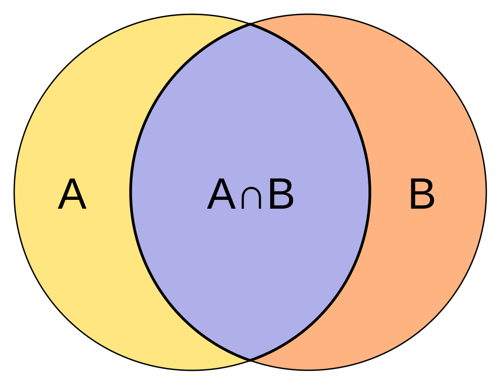

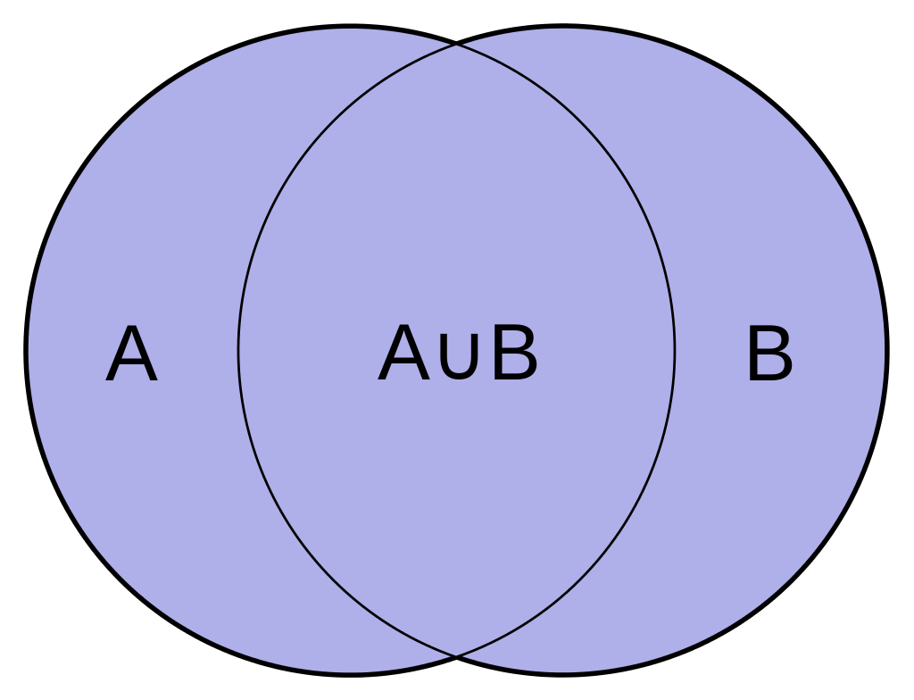

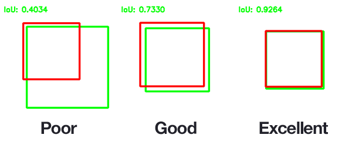

```r
simscore <- similarity(g, mode = 'out')

simscore[1:5, 1:5]
```

```
##             [,1]        [,2]        [,3]        [,4]       [,5]
## [1,] 1.000000000 0.007722008 0.026515152 0.111662531 0.04942966
## [2,] 0.007722008 1.000000000 0.000000000 0.004098361 0.01388889
## [3,] 0.026515152 0.000000000 1.000000000 0.003937008 0.01219512
## [4,] 0.111662531 0.004098361 0.003937008 1.000000000 0.04838710
## [5,] 0.049429658 0.013888889 0.012195122 0.048387097 1.00000000
```

```r
#Who are similar people?
poi_sim <- g %>%
  {
    #how similar are nodes to our person of interest?
    V(.)$simscore <- simscore[V(.)$name == person_of_interest];
    .;
  } %>%
  #remove person of interest
  {. - V(.)[name == person_of_interest]} %>%
  #remove movies the person of interest already saw
  {. - V(.)[name %in% poi_movies]}
```

We want to compare movies between two users that are actually similar to eachother, so we will need to create a cutoff point we decide upon.

```r
#pull just the people
raters <- poi_sim %>%
  tail_of(., E(.)) %>%
  unique()

raters
```

```
## + 609/10096 vertices, named, from 1d3888a:
##   [1] 2   3   4   5   6   7   8   9   10  11  12  13  14  15  16  17  18
##  [18] 19  20  21  22  23  24  25  26  27  28  29  30  31  32  33  34  35
##  [35] 36  37  38  39  40  41  42  43  44  45  46  47  48  49  50  51  52
##  [52] 53  54  55  56  57  58  59  60  61  62  63  64  65  66  67  68  69
##  [69] 70  71  72  73  74  75  76  77  78  79  80  81  82  83  84  85  86
##  [86] 87  88  89  90  91  92  93  94  95  96  97  98  99  100 101 102 103
## [103] 104 105 106 107 108 109 110 111 112 113 114 115 116 117 118 119 120
## [120] 121 122 123 124 125 126 127 128 129 130 131 132 133 134 135 136 137
## [137] 138 139 140 141 142 143 144 145 146 147 148 149 150 151 152 153 154
## [154] 155 156 157 158 159 160 161 162 163 164 165 166 167 168 169 170 171
## + ... omitted several vertices
```

```r
#make a cutoff to determine who are similar enough to poi
q3 <- quantile(raters$simscore, .95)

q3
```

```
##       95%
## 0.1518779
```

Now, we can filter out people we declare are not similar to our person of interest and then select moves that person of interest has not rated yet.

```r
poi_sim <- poi_sim %>%
  #remove people who are not similar to person of interest
  {
    allnames <- ego(. , nodes = V(.)[simscore > q3]) %>% #returns list
      unlist %>% #returns a vector of vertices
      names %>%
      unique

    . - V(.)[!name %in% allnames]
  } %>%
  #create metrics for movies
  {
    #degree is the sum of edges
    #strength is a the sum of edge attributes
    rate_score <- strength(., weights = E(.)$rating)/degree(.);
    V(.)$rate_score <- rate_score;
    V(.)$degree <- degree(.)
    . - tail_of(., E(.));
  }
```

```r
poi_sim %>%
  as_data_frame('vertices') %>%
  filter(degree > 5) %>%
  arrange(desc(rate_score)) %>%
  head(10) %>%
  select(-simscore) #simscore was used only to rate people
```

```
##                                                    name rate_score degree
## 1                                   12 Angry Men (1957)   4.666667      6
## 2                         No Country for Old Men (2007)   4.666667      6
## 3                  Bridge on the River Kwai, The (1957)   4.571429      7
## 4  Amelie (Fabuleux destin d'Amélie Poulain, Le) (2001)   4.571429      7
## 5                                  Trainspotting (1996)   4.533333     15
## 6                      Shawshank Redemption, The (1994)   4.525000     20
## 7                                         Brazil (1985)   4.500000     10
## 8                                 Godfather, The (1972)   4.500000     27
## 9                                     Roger & Me (1989)   4.500000      6
## 10               One Flew Over the Cuckoo's Nest (1975)   4.466667     15
```

## Yeah, but does it work?

```r
#let's get top movies
poi_top <- poi_ego %>%
  {
    q3 <- quantile(E(.)$rating, .75);
    . - E(.)[rating < q3]
  } %>%
  head_of(E(.)) %>%
  .$name %>%
  head(20)

poi_top
```

```
##  [1] "Seven (a.k.a. Se7en) (1995)"
##  [2] "Usual Suspects, The (1995)"
##  [3] "Bottle Rocket (1996)"
##  [4] "Rob Roy (1995)"
##  [5] "Canadian Bacon (1995)"
##  [6] "Desperado (1995)"
##  [7] "Billy Madison (1995)"
##  [8] "Dumb & Dumber (Dumb and Dumber) (1994)"
##  [9] "Star Wars: Episode IV - A New Hope (1977)"
## [10] "Tommy Boy (1995)"
## [11] "Jungle Book, The (1994)"
## [12] "Fugitive, The (1993)"
## [13] "Schindler's List (1993)"
## [14] "Tombstone (1993)"
## [15] "Pinocchio (1940)"
## [16] "Fargo (1996)"
## [17] "James and the Giant Peach (1996)"
## [18] "Wizard of Oz, The (1939)"
## [19] "Citizen Kane (1941)"
## [20] "Adventures of Robin Hood, The (1938)"
```

```r
recommend_movies <- function(g, person_of_interest){
  poi_ego <- g %>%
    ego(nodes = person_of_interest) %>%
    .[[1]] %>%
    {g - V(g)[!name %in% .$name]}

  poi_movies <- poi_ego %>%
    head_of(graph = ., es = E(.)) %>%
    unique %>%
    .$name

  simscore <- similarity(g, mode = 'out')

  poi_sim <- g %>%
    {
      V(.)$simscore <- simscore[V(.)$name == person_of_interest];
      .;
    } %>%
    {. - V(.)[name == person_of_interest]} %>%
    {. - V(.)[name %in% poi_movies]}

  raters <- poi_sim %>%
    tail_of(., E(.)) %>%
    unique()

  q3 <- quantile(raters$simscore, .95)

  poi_sim <- poi_sim %>%
    {
      allnames <- ego(. , nodes = V(.)[simscore > q3]) %>%
        unlist %>%
        names %>%
        unique

      . - V(.)[!name %in% allnames]
    } %>%
    {
      rate_score <- strength(., weights = E(.)$rating)/degree(.);
      V(.)$rate_score <- rate_score;
      V(.)$degree <- degree(.)
      . - tail_of(., E(.));
    } %>%
    as_data_frame('vertices') %>%
    arrange(desc(rate_score))
}
```

```r
poi_test <- g %>%
  {. - E(.)[person_of_interest %--% poi_top]} %>%
  recommend_movies(person_of_interest)
```

```r
poi_test %>%
  filter(degree > 5) %>%
  .$name %>%
  head(40) %>%
  {. %in% poi_top} %>%
  table
```

```
## .
## FALSE  TRUE
##    35     5
```